# Data Extraction from Scanned Genomics Reports Using an Optical Character Recognition Pipeline

#### *Chester Poon*

- Abstract
- Introduction
- Problem Statement
- Literature Review
- Methodology
  - Levenschtein Similarity Ratio
  - Image Preprocessing
  - OCR Pipeline Steps
- Results
- Conclusion and Next Steps
- References
- Appendix

## Abstract

Memorial Sloan Kettering Cancer Center (MSK) receives genetics reports from various vendors that are either faxed or scanned over and are stored in a MSK institutional data warehouse. These documents are only available as an image or pdf. The aim is to determine whether it is possible to automatically and accurately extract the appropriate elements from several different reports and to upload them into the institutional data warehouse. The primary model will utilize the Tesseract OCR software, which leverages a long-short term memory recurrent neural network (RNN) for text line and character recognition. The main pipeline will consist of four stages where all relevant data from the OCR process will be confirmed using the Levenschtein similarity ratio. 1) The header of the document will be isolated to identify the document type. 2) The first page of every report, which contains the main data elements we need, will be identified and isolated. All other pages such as fax cover sheets, disclaimer sheets and other pages of the report remain irrelevant. 3) The middle region of the first page will be isolated to determine whether the patient is positive or negative for a clinically significant genetic mutation. 4) The same region from step three will be used to determine which genes are affected by the mutation if they exist. Any data element that appears to be ambiguous in any of the four stages will be flagged as requiring manual review. Running the final model pipeline over 143 documents was 99.3% accurate with only a single document requiring manual review.

**Keywords**: Tesseract, OCR, Levenschtein similarity ratio, Long-short term memory RNN, Genetic Mutation, Cancer

## Introduction

According to the Center for Disease Control and Prevention, cancer is the second leading cause of death in the United States (Centers for Disease Control and Prevention, 2020). More research is needed to better understand and treat it and one of the best modern methods in the fight against cancer is personalized medicine. Personalized medicine is dependent on the findings of a patient genetic profile to be able to find the most effective treatment available to them. Understanding more about the genetic structure of a patient can help us better assess cancer risk, find the most effective treatment for them, and ultimately save lives.

Memorial Sloan Kettering Cancer Center (MSK) in New York City, is one of the top cancer research hospitals in the country. Most of the genetic testing is done in-house and the results are stored in the data warehouse in a structured format making it easy for scientists and physicians to access the data for research. However, a small but not insignificant portion of patients get their testing from external sources or vendors. That information is often faxed or mailed over and is scanned into the database as PDF files. Unfortunately, that data is not as easily or readily extractable. For a single research project, this could potentially lead to many hours of manual text extraction and data entry.

## Problem Statement

While the genomics data from outside vendors is likely stored electronically, sharing patient health information (PHI) across institutions likely requires at least some form of business partnership. These vendors also might not possess the technological infrastructure for easy data transfer. Ideally, external genomics reports need to be parsed out into structured data elements to allow for easy analysis for cancer research. Because MSK can receive genomics reports from various vendors, the reports can arrive in many different formats and contain quite a bit of other text that is not relevant to most research. To compound the problem, sometimes the format of the documents from the same vendor can change from year to year. The goal of this project is to determine if it is possible to automate the extraction of relevant data elements from the appropriate regions of the genomics reports and upload them into the data warehouse.

## Literature Review

Because the primary engine for this project will be the Tesseract OCR software, the focus of this literature review will be to review the research on optical character recognition that has led to the current version of Tesseract OCR available today.

There are several methods for identifying the region of interest (ROI) of a document that has been researched in addressing the problem of digitizing the text of scanned documents. Those methods are the bottom-up method, the top-down method, and a whitespace analysis in identifying the text regions of a document (Smith R. , 2009). Bottom-up methods classify the small pieces of an image such as pixels or groups of connected pixels. After those small pieces are classified, the algorithm then groups together similar types to form regions. Top-down methods take a different approach in that it cuts the image with vertical and horizontal lines along the white spaces of a document in the image, such as the whitespaces that divide columns or paragraphs. Instead of analyzing the pixels in the document, an analysis of the whitespace is done to identify regions of text.

Chowdhury et al. explore a bottom-up approach to text and graphic segmentation (Chowdhury, Mandal, & K, 2007). They first convert the image to grayscale, remove the half-tones and the document is converted to binary where “Otsu’s method” is applied, which classified pixels as foreground or background (Otsu, 1979). “Otsu’s method”, which was developed by Nobuyuki Otsu as a method of automatic image thresholding, uses linear discriminant analysis to classify those pixels into either the foreground or background classes. For optical character recognition, this can be very useful in filtering out noise in gray-scale document images in that it clearly defines a character (foreground) from its background. Segmentation of the document then starts with classification of pixels or groups of pixels into various buckets that are later used to define if the segment is either a graphic or just noise. Chowdhury et al. take special care and attention to dashed and dotted lines, which is a defining aspect of this paper that differentiates it from other papers that address the bottom-up approach to segmentation.

The top-down approach can be exemplified from the work of Nagy & Seth where they correctly operated on the assumption that most documents can be divided into rectangular blocks or partitions where each rectangle is a node or a leaf in an X-Y tree (Nagy & Seth, 1984). Lines are drawn horizontally and vertically throughout the page based on the location of whitespace in the document. There are clear limitations to this approach as the top-down method only partitions a document into rectangles and cannot account for regions where the text or graphic does not conform to a rectangular shape.

There is an obvious disadvantage to top-down approaches when dealing with oddly laid out text, which bottom-up approaches handle with relative ease. However, Ray Smith identifies a disadvantage with bottom-up approaches where there can be over-segmentation of the page layout and may have a difficult time identifying text columns (Smith R. , 2009). To account for the disadvantages of both approaches, Smith combines bottom-up and top-town methods into a hybrid method employing a bottom-up approach in identifying a top-down structure. Part of this method, uses a bottom-up approach in identifying tab-stops to identify regions such as the start of a paragraph and the column layout.

Before any method can be deployed in identifying the region of interest (ROI) containing text, preprocessing the image is of utmost importance. Thakare et al. presents a preprocessing method for each image in order to optimize the identification of the ROI in preparation for optical character recognition (OCR) (Thakare, Kamble, Thengne, & Kamble, 2018). One of the most common issues that comes with scanned documents is the potential for the page to be stored in such a way where the text can be skewed significantly, negatively impacting any OCR algorithm that is deployed. Detecting the skew of a scanned document and correcting that skew is therefore vital. Li et al. employs a solution that uses the white space between text lines to determine the degree of skew in a document (Li, Breier, & Merhof, 2015). They were able to develop an effective method of skew detection and reorientation.

Once image preprocessing is complete, OCR can be applied to read the text on a document. There are a number of OCR engines available for use and the two that are of particular interest is Tesseract OCR and OCRopus (Comparison of optical character recognition software, 2020).

Tesseract OCR is a widely known powerful open source OCR engine originally conceived and developed at HP Labs (Smith R. , An Overview of the Tesseract OCR Engine, 2007). Tesseract has many features out of the box that produces accurate results for character recognition. De-skewing is built into tesseract using the algorithm Smith developed that looks at the text lines to determine the angle of skew (Smith R. , A simple and efficient skew detection algorithm via text row accumulation, 1995). There is also baseline fitting using a quadratic spline out of the box that solves any issues with curved text, but Smith does acknowledge that there is a limitation if there are more curves in the text where perhaps a cubic spline is more appropriate. Tesseract then does word recognition and detects fixed pitch or non-fixed pitch words. Fixed pitch words and letters are easier to define, but Smith makes clear the challenge of recognizing non-fixed pitch characters and word spacing. Non-fixed pitched letters are italicized fonts and there is also difficulty in reading words where the spacing may not be proportional such as digits and punctuation (Smith R. , An Overview of the Tesseract OCR Engine, 2007). According to Smith, “Tesseract solves most of these problems by measuring gaps in a limited vertical range between the baseline and mean line. Spaces that are close to the threshold at this stage are made fuzzy, so that a final decision can be made after word recognition (Smith R. , An Overview of the Tesseract OCR Engine, 2007).” Word recognition is then initiated through segmentation via line finding and then applies a character chopping algorithm to identify individual characters. Character classification then undergoes a two-step process where a list of potential character classes is generated that could be a potential match. The second step determines the similarity between each candidate character class and then classifies the character that is most similar. The latest version of the Tesseract OCR engine now uses a LSTM (Long-short term memory) neural network to improve line recognition in the document (tesseract-ocr, 2020).

OCRopus is another open source OCR engine and was originally developed to handle large scale OCR of scanned images (Breuel, The OCRopus Open Source OCR System, 2008). The core architecture of OCRopus focuses on three major pieces: layout detection/analysis, text line recognition, and statistical language monitoring. It attempts to combine many of the pieces relevant to this project. The layout detection algorithm as a first step separates the document into different regions and then classifies each region of text, images and other types using logistic regression. It utilizes a RAST-based layout analysis using one algorithm for whitespace identification and another for text line finding (Breuel, High performance document layout analysis, 2003). The next step is in text line recognition and OCRopus utilizes two text line recognizers: Tesseract OCR and MLP-based recognition. Tesseract OCR, we have already discussed at length previously. MLP (multi-layer perceptrons) based recognition, according to Breuel, first attempts “oversegmentation of the input string, then recogniz[es] each potential character hypothesis, and finally express[es] both the recognition results and the geometric relationships between character hypotheses as a graph structure (Breuel, The OCRopus Open Source OCR System, 2008).”

Advances of OCRopus and Tesseract OCR have both come a long way in their development over the years since the research papers of both OCR engines were originally released. OCRopus is now maintained by a developer community. Similar to Tesseract OCR, it also now utilizes an implementation of LSTM (long-short term memory) recurrent neural network for the text line recognizer (ocropy, 2020). Though both OCRopus and Tesseract OCR could be equally useful for this project, Tesseract OCR is far more mature and thus the preferred choice.

## Methodology

For the purpose of this project, there are three separate genetic reports that are included for the ETL process. A total of 143 documents were reviewed for evaluation and development of the OCR algorithm: 69 GeneDx, 6 Myriad myChoice, and 68 Myriad BRACAnalysis reports. Each report type is nuanced on how gene mutations are reported. It is important that an algorithm is developed in a way that will reduce the amount of processing power necessary for the model to run. The first step for each image will be to first determine the orientation of the text and then to deskew the image if necessary. The next step would be to identify the first page of each report because the first page contains the relevant data we need to be extracted. For any multi-page documents, all other pages other than the first page of the report will be discarded. The region of interest (ROI) is then identified to extract the report elements we need. Image preprocessing will then be applied to the ROI just prior to implementing optical character recognition. The Tesseract OCR model will then be used for OCR, which uses a long short-term memory model for line extraction and character recognition to extract the text in that region (tesseract-ocr, 2020). Rather than using typical natural language processing techniques, the appropriate data we need will then be identified from determining the highest calculated Levenschtein similarity ratio of relevant objects.

#### Levenschtein Similarity Ratio

The Levenschtein distance, named after the Soviet mathematician, Vladimir Levenschtein is a method of calculating how far apart two separate character sequences are (Wikipedia, 2020). Rather than use the distance in our calculations the similarity ratio is used instead. The formal definitions for Levenschtein distance and the similarity ratio can be seen in figures 1 and 2 (Arias, 2020).

[figure not shown]

*Figure 1. Formal definition of the Levenschtein distance*

[figure not shown]

*Figure 2. Formula for Levenschtein similarity ratio where |a| is the length of sequence **a** and |b| is the length of sequence **b**.*

#### Image Preprocessing

Each scanned document can vary in quality and some documents have significant amounts of noise, which can make characters in the document difficult to classify correctly. For example, in the Myriad MyChoice documents, one of the core data elements needed for extraction is embedded within a gray or black block (see figure 3).

[figure not shown]

*Figure 3. Varying degrees of image quality for core data element in the report*

As evidenced above, there are documents with a clear black background, whereas other documents have varying levels of noise that can make character edge detection difficult. For images with any noise as evidenced in figure 3, a lower quality image is preferable over a high quality one because a lower quality image naturally removes smaller pixel noise that would be visible otherwise. Typically, this method of resizing the image to be a lower quality is only a first step in eliminating small pixel noise as seen in figures 4 and 5.

[figure not shown]

*Figure 4. Higher quality image*

[figure not shown]

*Figure 5. Lower quality image*

When lowering the quality, there is a noticeable difference in that the black parts of the box have bled into other black pixels essentially blurring the image a bit. After the initial first step of intentionally reducing the image quality, we can see the noise appears mostly black or dark gray. The image in figure 5 still appears to contain half tones, which is easily solvable with Otsu thresholding and inversion. Otsu thresholding binarizes the images and removes half tones that more clearly identifies letters in the image as seen in figure 6.

[figure not shown]

*Figure 6. Otsu thresholding and inversion off of the lower quality image*

The inversion also cleared up a bit more of the noise in the image, which preps the image a bit further for more effective OCR. Another step must be taken to further reduce noise.

[figure not shown]

*Figure 7. Median blur applied to figure 6*

Our next step uses a median blur with a kernel size of 5 to significantly remove much of the noise. Essentially, a median blur takes all the pixels and calculates the median under the kernel, replacing the pixels within the kernel size aperture with the calculated median value. Because we already binarized the image with Otsu thresholding, all pixel values are either 0 (white) or 255 (black). For the purpose of maintaining a value of only 0 or 255 within a kernel size aperture, only odd-sized kernels are used.

$$\begin{matrix} 0 & 0 & 0 & 255 & 0 \\ 0 & 255 & 255 & 255 & 255 \\ 0 & 255 & 255 & 0 & 255 \\ 255 & 255 & 0 & 255 & 255 \\ 255 & 255 & 255 & 255 & 255 \end{matrix}$$

*Figure 8. Pixel matrix with kernel size of 5*

[figure not shown]

*Figure 9. Bilateral Filter applied to image in figure 7*

Of course, not all images need to go through all the image preprocessing steps mentioned above. Some will need a minimum level of processing for accurate OCR, while other images will need to run the full gamut of steps. The steps that are taken will depend upon which step generates the highest Levenschtein similarity ratio for each data element. Because each data element within the report will also have different requirements regarding preprocessing, it would be impractical to go through each document to determine how to preprocess each element for OCR. A programmatic methodology must be applied to bring the algorithm to scale to accurately read thousands of documents and each document will have a different methodology for extracting data elements.

Because one line or section of a report could be read with the OCR model perfectly well, the very next line or section could still have poor results. In order to handle this issue, all image qualities and preprocessing methods are applied to the same image. The OCR model will then be applied to each preprocessed image in order until the text can be extracted accurately. Accuracy will be determined using the Levenschtein similarity ratio as discussed earlier. Once an accurate reading is obtained, the data will be extracted and loaded into the dataset. To use a previous example, one of the elements from the Myriad myChoice report is the Myriad HRD status. The actual value of interest is the text immediately after “Myriad HRD Status” (see figures 3-7, 9). The algorithm extracts that value from the report based on the line location of “Myriad HRD Status”. An example of the results from the extraction process can be seen in figure 10.

[figure not shown]

*Figure 10. Example of OCR extraction*

The element column shows the data element that is being extracted from the document. Once the line has been identified as having the highest similarity ratio for the element in question, a “positive” or “negative” result is extracted from the line depending on the similarity ratio calculated for the word “positive” or the word “negative”. The “pos” and “neg” columns indicate the similarity ratio for those words. The higher ratio determines the result in the result column. The method column indicates the level of preprocessing that was necessary to obtain an accurate reading of the text for that line. In the example in the “method” column, “orig_hi” indicates that there was no preprocessing done and the characters were extracted using the higher quality image. The “median_blur” method on line two in the table indicates that characters were extracted using the lower quality image with the application of a median blur after Otsu thresholding was applied as was done in figures 6 and 7.

#### OCR Pipeline Steps

The first step that needs to be taken is to determine if the image is oriented correctly. If it is not, a de-skewing function is applied to the document, which leverages the LSTM algorithm from Tesseract. Next, irrelevant pages need to be removed from the report. The purpose of the project is to extract the results of the genetic test. Any information about various disclaimers, how the genetic test was done or other information about the lab conducting the test is not needed for genetic test results. Those results typically exist around the top two-thirds of the first page of the report. Unfortunately, there are pages that are fax cover sheets that were scanned in with the report and there are pages in the report filled with other information that is either superfluous or redundant that spill onto a second page. The easiest way to determine which page is the first page of the report is to identify the name of the report. For our purposes, only three different reports exist in our data: Genetic Test Report GeneDx, Myriad myChoice, and Myriad BRACAnalysis (figure 11).

[figure not shown]

*Figure 11. The first page of the Genetic Test Report GeneDx, Myriad myChoice, Myriad BRACAnalysis reports. Patient information is redacted from the image.*

After de-skewing the document where applicable, the report header has to be identified. Whichever page appears first in the order of the document that contains the report name (Myriad myChoice, Myriad BRACAnalysis, and GeneDx) within the header is the first page of the report. To do this, the top 1/6th of each page of the scanned document is isolated as our region of interest (see figure 12). A median blur with a kernel size of 11 is automatically applied to remove any existing noise. The Tesseract OCR model is run over the header region and the line with the highest similarity ratio for one of the three report names is identified. If the scanned document is a multi-page document, the first page of the document is identified as whichever page is the first to surpass the similarity ratio threshold of 0.8. All remaining pages can be discarded if there are any.

The next step will be to identify the region where the important report elements are located. That region for all three of our report types are located from below the header to slightly below the midway point in the document. The document has already been divided into six regions with the top region representing the document header. For this piece of the pipeline, the header is removed along with the bottom third of the document with the assumption that all important report elements are located in the top 2/3rds of the document minus the header (see figure 12).

[figure not shown]

*Figure 12. Example of relevant sections identified from the page. The header to identify the report type and the middle region to identify the relevant report elements.*

[figure not shown]

*Figure 13. A negative result for genetic mutation for a patient*

[figure not shown]

*Figure 14. Positive results for mutation*

Once the summary result has been identified and extracted, the gene data is then the natural next step. It is important to note that regardless of the result summary in the report, a genetic variant may still be identified and must be extracted. A corpus of 21 genes were used for this OCR pipeline to identify the relevant genes through Levenschtein similarity ratio. Because many of these genes have a similarity ratio to each other as high as 0.8 or more, these genes must be an exact match or have a 1.0 similarity ratio to a gene in the corpus to be properly identified. Once the gene is identified, all other data following the gene is also extracted. For the purposes of the OCR pipeline evaluation, only the gene will be considered.

[figure not shown]

*Figure 15. Model Pipeline Diagram*

## Results

| Metric | Ratio | Accuracy |
| --- | --- | --- |
| Report Type Accuracy | 143/143 | 100.0% |
| Relevant Page Identification | 143/143; 96/96 | 100.0% |
| Genetic Aberration Detection Accuracy | 142/143 | 99.3% |
| For Positive Mutations, Gene Identification Accuracy | 27/29 | 93.1% |

*Table 1. Accuracy metrics for each stage of element identification.*

The first two stages of the model pipeline are to determine which of the three genetic report types is being read and then to identify the first page of the report. For the 143 documents, all 143 documents were identified correctly making this part of the model pipeline 100% accurate. This is not a surprising outcome given the relative simplicity of this stage of the pipeline. Titles of documents are always located on the page header with the largest and clearest fonts. Given that there are only three different reports to identify with significantly different names, calculating the Levenschtein similarity ratio boosted accuracy to perfect or near-perfect results. The next part of the process is primarily for multi-page documents and determines which page is relevant for our OCR extraction. Against only the multipage documents in the dataset, which make up 96 documents out of the 143, 100% of the documents had the correct page identified as the relevant page. The algorithm identifies the first page of the report as the page that first indicates success in identifying the report type.

The third stage classifies the patient as either positive or negative for a genetic aberration or mutation. The results were very accurate at 99.3%. The confusion matrix below illustrates the single false negative record that was misidentified. Fortunately, as intended the algorithm flagged this result as necessary for manual review.

[figure not shown]

*Figure 16. Confusion matrix for final model pipeline*

| Positive/Negative Result Metrics |  |
| --- | --- |
| Accuracy | 99.3% |
| Sensitivity (True Positive Rate) | 0.95 |
| Specificity (True Negative Rate) | 1.00 |
| Fallout (False Positive Rate) | 0.00 |
| Precision | 1.00 |
| F1 Score | 0.98 |

*Table 2. Performance metrics for stage 3 of the final model pipeline.*

Because there was only one report that required manual review, a deep dive indicated that this particular document had significant salt and pepper noise throughout. Unlike most salt and pepper noise, this document had grains that were the same size or slightly smaller than the actual letters of the document (see Figure 17). The significant noise not only made the characters difficult to read, but also difficult for the model to recognize text lines.

[figure not shown]

*Figure 17. Significant salt and pepper noise in the example section of the document.*

The final stage of the pipeline is to correctly identify the affected genes indicated in the report. Of all stages, this did not perform as well as the rest, but still performed fairly well and was 93.1% accurate. There are 22 patients that are positive for mutation and a few of those patients are positive for more than one affected gene. The goal is to identify the genes that are indicated as affected in the report for extraction. In order to assess the performance of this stage in the process, each observation in the dataset represents an affected gene linked to the patient. A brief example can be seen in table 3.

| Patient Record | Gene |
| --- | --- |
| MRN1 | BRCA1 |
| MRN2 | BRCA1 |
| MRN2 | BRCA2 |
| MRN3 | PALB2 |

*Table 3. Example of patients linked to mutated gene.*

There is a total of 29 observations in the true dataset. The model successfully predicted 27 of those observations. One of the two observations that was unsuccessfully identified comes from the document discussed earlier with significant “large-grain” salt and pepper noise. The second miss came from a Myriad BRACAnalysis document with a significant deviation from the standard document format. Typically, with the various formats for this particular report and other reports, the reported genetic aberration is located directly under the section that indicates if the patient is positive or negative for mutation and the algorithm looks in this region for those details. In this report for this particular patient, there are two genetic mutations identified. The model successfully captured one of the mutations but had missed the other (see Figure 18). The other mutation, in this case a mutation in the PALB2 gene, is beyond the typical region of interest and is not considered.

[figure not shown]

*Figure 18. Example of unusual format for Myriad BRACAnalysis document.*

## Conclusion and Next Steps

Given the promising results, it is certainly reasonable to use this OCR pipeline in automating the data extraction from scanned genomics reports. There were four major stages in the process. The first stage identified the genetic report type. The second identified the primary page that contained the relevant data elements. The third stage determined if the patient was positive or negative for a clinically significant mutation and the fourth stage identified the affected genes if the patient was positive.

Of the 143 documents used in testing the pipeline, all documents were identified correctly and all documents also had the correct page identified as the primary page. Only one document was categorized as a miss and was flagged as required manual review to assess positive or negative status for a clinically significant mutation. This one miss also led to a downstream miss that indicated the need for manual review to assess what gene was involved in the mutation. In assessing the final stage of the process, excluding the downstream miss that was just discussed, only one document missed 1 out of 2 affected genes. It seems that if the data elements only fall within a number of predetermined classifications, the combination of the Tesseract OCR software which utilizes a long-short term memory RNN model in combination with the utilization of the Levenschtein similarity ratio could reliably provide extremely accurate results.

Despite the promising results, testing over another cohort of documents would be ideal to assess the true viability of the model. The dataset was also significantly imbalanced where Myriad myChoice documents only made up 6 of the 143 documents, which is only just over 4% of the entire dataset. More of those genetic report types must be evaluated to test the viability of the model over those report types. Nevertheless, the algorithm appears to be very accurate and reliable in extracting the correct data elements for a set of predetermined classes. If a second run of the model over a different set of documents were successful, it would be ideal if a more advanced model could be built from the foundation of this one. Currently, this algorithm identifies the genetic report type and classifies it as one of a number of predetermined report types (Myriad myChoice, Myriad BRACAnalysis, GeneDx). A natural next step would be to develop a model pipeline that would classify the genetic report type without the need for creating a fixed and predetermined set of genetic report types. The way the algorithm is built now, the amount of maintenance required is potentially high if different genetic report types from other vendors are introduced into the data. A more advanced model could reduce the level of oversight and further automate the process.

## References

Arias, F. J. (2020, Nov 23). *Fuzzy String Matching in Python.* Retrieved from Datacamp:

https://www.datacamp.com/community/tutorials/fuzzy-string-python

Breuel, T. M. (2003). *High performance document layout analysis.* Symposium

on Document Image Understanding.

Breuel, T. M. (2008). The OCRopus Open Source OCR System. *Electronic Imaging.*

Centers for Disease Control and Prevention. (2020, Nov 22). *Leading Causes of Death.* Retrieved

from Centers for Disease Control and Prevention: https://www.cdc.gov/nchs/fastats/leading-causes-of-death.htm

Chowdhury, S. P., Mandal, S., & K, D. A. (2007). *Segmentation of Text and Graphics from Document Images.*

Proc. of the 9th Int. Conf. on Document Analysis, 619-623.

*Comparison of optical character recognition software.* (2020, Oct 2). Retrieved from Wikipedia:

https://en.wikipedia.org/wiki/Comparison_of_optical_character_recognition_software

Li, W., Breier, M., & Merhof, D. (2015). *SKEW CORRECTION AND LINE EXTRACTION IN BINARIZED PRINTED TEXT IMAGES.*

2015 IEEE International Conference on Image Processing (ICIP), 27-30.

Nagy, G., & Seth, S. G. (1984). *Hierarchical Representation of Optically Scanned Documents.*

Proc. 7th Int. Conference on Pattern Recognition (ICPR), 347-349.

*ocropy.* (2020, Oct 3). Retrieved from Github: https://github.com/ocropus/ocropy

OpenCV. (2020, Nov 23). *Smoothing Images.* Retrieved from OpenCV: Open Source Computer Vision:

https://docs.opencv.org/master/d4/d13/tutorial_py_filtering.html

Otsu, N. (1979). *A threshold selection method from gray-level histogram.* IEEE Transactions

on Systems, Man, and Cybernetics, 62-66.

Smith, R. (1995). *A simple and efficient skew detection algorithm via text row accumulation.*

Proceedings of 3rd International Conference on Document Analysis and Recognition, 14-16.

Smith, R. (2007). *An Overview of the Tesseract OCR Engine.* Ninth International Conference on

Document Analysis and Recognition (ICDAR 2007), 23-26.

Smith, R. (2009). *Hybrid Page Layout Analysis via Tab-Stop Detection.* 10th International Conference

on Document Analysis and Recognition, 241-245.

tesseract-ocr. (2020, Nov 15). *Tesseract User Manual.* Retrieved from tessdoc:

Tesseract documentation: https://tesseract-ocr.github.io/tessdoc/

Thakare, S., Kamble, A., Thengne, V., & Kamble, U. R. (2018). *Document Segmentation and Language Translation Using Tesseract-OCR.*

2018 IEEE 13th International Conference on Industrial and Information Systems (ICIIS), 148-151.

Wikipedia. (2020, Nov 23). *Levenshtein distance.* Retrieved from Wikipedia:

https://en.wikipedia.org/wiki/Levenshtein_distance

## Appendix

```python
from pdf2image import convert_from_path
import cv2
import pytesseract
import os
import imutils
import re
import numpy as np
from fuzzywuzzy import fuzz
import pandas as pd

# other libraries not needed for prod
import seaborn as sns
import matplotlib.pyplot as plt

pytesseract.pytesseract.tesseract_cmd = 'C:\\Program Files\\Tesseract-OCR\\tesseract.exe'
```

### preprocessing image

```python
# get levenschtein distance
def lev_dist(var, string, lower=True):
    if lower == True:
        return fuzz.partial_ratio(var.lower(),string.lower())
    else:
        return fuzz.partial_ratio(var,string)
```

```python
def get_ocr(img):
    # split the lines into a list
    lines = pytesseract.image_to_string(img).split('\n')
    lines = [l for l in lines if l.strip() != '']
    lines = [l for l in lines if len(l) >= 10] # set minimum OCR "success" minus 2(minimum length error)

    return lines
```

```python
def get_high_lev(element, opt_dict, brca=False):
    # get the highest levenschtein distance
    df = pd.DataFrame(
        {
            'element':[],
            'line':[],
            'line_index':[],
            'lev_dist':[],
            'method':[]
        }
    )
    for k in opt_dict.keys():
        for i in range(len(opt_dict[k])):
            if brca==False:
                if element == 'Genetic Test Report GeneD':
                    ld = lev_dist(element, opt_dict[k][i],lower=True)
                else:
                    ld = lev_dist(element, opt_dict[k][i],lower=False)
                df = df.append(
                    {
                        'element': element,
                        'line':opt_dict[k][i],
                        'line_index': i,
                        'lev_dist':ld,
                        'method': k
                    }, ignore_index=True
                )
            else:
                df = df.append(
                    {
                        'element': element,
                        'line':opt_dict[k][i],
                        'line_index': i,
                        'lev_dist':lev_dist(element, opt_dict[k][i][:4],lower=False),
                        'method': k
                    }, ignore_index=True
                )
    df['rank_num'] = df.lev_dist.rank(ascending=False, method='min')
    df = df[df.rank_num==1]

    return df
```

```python
def preprocess(pdf):
    """convert pdf from path to PIL image
    then save file and reload to convert to opencv image"""
    pil_imgs = convert_from_path('PDF files/' + pdf, size=3500, grayscale=True)
    filename = re.findall('.*(?=\.pdf)', pdf)[0]
    folder = 'images/' + filename

    try:
        os.mkdir(folder)
    except FileExistsError:
        print('file already exists. skipping "mkdir"')

    cv_imgs = {}

    for i in range(len(pil_imgs)):
        pic_name = folder + '/' + filename + '_' + str(i) + '.jpg'
        pil_imgs[i].save(pic_name)
        cv_imgs.update(
            {
                i:
                cv2.imread(pic_name,0)
            }

        )

    # determine orientation and deskew image if necessary
    orientation = int(
        re.findall(
            '(?<=Orientation in degrees: ).*',
            pytesseract.image_to_osd(cv_imgs[0])
        )[0]
    )

    for i in cv_imgs.keys():
        cv_imgs[i] = imutils.rotate(cv_imgs[i], angle=orientation) # reorient/deskew
        roi = cv_imgs[i][0:int(cv_imgs[i].shape[0]/6), 0:cv_imgs[i].shape[1]] # identify top region to determine type of report
        roi = cv2.medianBlur(roi,11) # apply median blur kernel size 11 for all report headers
        opt_dict = {'median_blur': get_ocr(roi)}

        # levenschtein distance threshold set at 80
        if get_high_lev('Genetic Test Report GeneD',opt_dict)['lev_dist'].iloc[0] >= 80:
            test = 'Genetic Test Report GeneDx'
            index=i
            break
        elif get_high_lev('Myriad myChoice',opt_dict)['lev_dist'].iloc[0] >= 80:
            test = 'Myriad myChoice'
            index=i
            break
        elif get_high_lev('BRACAnalysis',opt_dict)['lev_dist'].iloc[0] >= 80:
            test = 'Myriad BRACAnalysis'
            index=i
            break
        else:
            test = 'Unknown'
            index=0

    # now relevant pic is determined, get lower quality version
    pic_name = folder + '/' + filename + '_' + str(index) + '_lo.jpg'
    hi_pil = convert_from_path('PDF files/' + pdf, size=2000, grayscale=True)[index]
    hi_pil.save(pic_name)

    hi_lo = [
        cv_imgs[index], # hi quality pic
        imutils.rotate(cv2.imread(pic_name,0), angle=orientation) # lo quality pic
    ]

    return {
        filename: {
            'test_name': test,
            'pic_list':hi_lo
        }
    }
```

```python
images = {}

for i in os.listdir('PDF files'):
    images.update(preprocess(i))
```

[output not shown]

[output cut: 88 more lines]

[output not shown]

### Test name validation

```python
test_name_df = pd.DataFrame({
    'MRN':list(images.keys()),
    'test_name': [images[i]['test_name'] for i in list(images.keys())]
})

test_validate = pd.read_excel('validation_data.xlsx', converters={'MRN': str})

test_name_chk = pd.merge(
    test_name_df,
    test_validate[test_validate.columns[:2]],
    on='MRN',
    how='inner'
)

test_name_chk['concordance'] = test_name_chk.apply(
    lambda x: True if x.test_actual.lower() in x.test_name.lower() else False, axis=1
)

print(test_name_chk['concordance'].value_counts())
print(len(test_name_chk))
```

```
True    143
Name: concordance, dtype: int64
143
```

```python
def neg_pos(df):
    df['neg'] = df.line.apply(lambda x: lev_dist('nega',x))
    df['pos'] = df.line.apply(lambda x: lev_dist('posi',x))
    df['result'] = df.apply(lambda x: 'Positive' if x.pos >= x.neg else 'Negative', axis=1)
    return df
```

### myChoice

```python
def mychoice(mrn, test_name, opt_dict, th):
    df = pd.concat(
        [
            get_high_lev('GIS Status',opt_dict).iloc[:1],
            get_high_lev('Myriad HRD Status',opt_dict).iloc[:1],
            get_high_lev('BRCA1/BRCA2 Status',opt_dict).iloc[:1]
        ]
    )

    # determine positive or negative status
    df = neg_pos(df)

    df.result = df.apply(
        lambda x: 'Needs Manual Review' if x.lev_dist <= th else x.result, axis=1 # threshold originally set at 75
    )

    if len(df[(df.element == 'BRCA1/BRCA2 Status') & (df.result=='Positive')]) > 0:

        result_df = get_high_lev('GENE CLINICALLY SIGNIFICANT MUTATION(S) INTERPRETATION', opt_dict).iloc[:1]
        result_df['line_after'] = result_df.apply(
            lambda x: opt_dict[x.method][int(x.line_index + 1):int(x.line_index + 5)], axis=1 #get line after test results and interpretation
        )

        results_list = [i[:5] for i in result_df.iloc[0].line_after]
        brca2 = get_high_lev('BRCA2', {result_df.iloc[0].method: results_list})

        if brca2.iloc[0].lev_dist == 100:
            li = int(brca2.iloc[0].line_index)
            brca2_line = result_df.iloc[0].line_after[li]
            brca2_line = brca2_line[6:]
            results_list.pop(li)
        else:
            brca2_line = 'Negative'

        brca1 = get_high_lev('BRCA1', {result_df.iloc[0].method: results_list})

        if brca1.iloc[0].lev_dist >= 80:
            brca1_line = result_df.iloc[0].line_after[int(brca1.iloc[0].line_index)]
            brca1_line = brca1_line[6:]
        else:
            brca1_line = 'Negative'
    else:
        brca2_line = 'Negative'
        brca1_line = 'Negative'

    df.insert(0, 'MRN', mrn[:8])

    data_df = df[['MRN', 'element', 'result']].pivot(
                    index='MRN',
                    columns='element',
                    values='result'
                ).reset_index()

    data_df['BRCA1'] = brca1_line
    data_df['BRCA2'] = brca2_line

    data_df.insert(1, 'Test', test_name)

    gene_df = pd.DataFrame({
        'Gene': [],
        'Text Result': []
    })

    if brca1_line != 'Negative':
        row = {'Gene':'BRCA1', 'Text Result':brca1_line}
        gene_df = gene_df.append(row, ignore_index=True)

    if brca2_line != 'Negative':
        row = {'Gene':'BRCA2', 'Text Result':brca2_line}
        gene_df = gene_df.append(row, ignore_index=True)

    if len(gene_df) == 0:
        gene_df = pd.DataFrame({
            'MRN': [mrn],
            'Gene': [None],
            'Text Result': [None]
        })
    else:
        gene_df.insert(0, 'MRN', mrn)


    return {
        'eval': df.reset_index(drop=True),
        'data': data_df,
        'genes': gene_df
           }
```

### Gene df creator

```python
def get_genes(mrn, gene_list, li, opt_dict):
    gene = []
    res = []

    for g in gene_list:
        temp_gene = get_high_lev(g, opt_dict)
        temp_gene = temp_gene[(temp_gene.line_index > li) & (temp_gene.line_index <= li + 7)]

        # Gene has to be roughly in the beginning of the string
        temp_gene['x'] = temp_gene.line.apply(lambda x: 1 if g.lower() in x[:10].lower() else 0)
        temp_gene = temp_gene[temp_gene.x == 1]

        # Line cannot contain indications that test was negative for gene
        temp_gene.x = temp_gene.line.apply(
            lambda x: 0 if lev_dist('No Mutation',x) > 70
                        or lev_dist('negative',x) > 70
                        or lev_dist('not detected',x) > 80
                        or lev_dist('not observed',x) > 80
            else 1
        )
        temp_gene = temp_gene[temp_gene.x == 1]

        if len(temp_gene) > 0:
            gene.append(g)
            res.append(temp_gene.iloc[0].line)

    gdf = pd.DataFrame({
        'Gene': gene,
        'Text Result': res
    })

    # Gene must be the only one on the line
    gdf['keep'] = gdf['Text Result'].apply(lambda x: 'y' if len([i for i in gene_list if i in x]) == 1 else None )
    gdf = gdf[gdf.keep == 'y']
    gdf.insert(0,'MRN',mrn)
    return gdf.iloc[:,:3]
```

### BRACAnalysis

```python
def bracanalysis(mrn, test_name, opt_dict, gene_list, th):
    df = get_high_lev('RESULT:', opt_dict).iloc[:1]
    df = neg_pos(df)
    df.insert(0, 'MRN', mrn[:8])

    df = df[df.lev_dist >= th]

    if len(df) == 0 or df.iloc[0].result != 'Negative':
        if get_high_lev('Test Results and Interpretation', opt_dict)['lev_dist'].iloc[0] >= th:
            df = get_high_lev('Test Results and Interpretation', opt_dict)
            df.insert(0, 'MRN', mrn[:8])
            flag = 'v1'
            result_df = df.copy()
        elif get_high_lev('GENE MUTATION INTERPRETATION', opt_dict)['lev_dist'].iloc[0] >= th:
            df = get_high_lev('GENE MUTATION INTERPRETATION', opt_dict)
            df.insert(0, 'MRN', mrn[:8])
            flag = 'v2'
            result_df = df.copy()
        elif len(df) == 0:
            return {
                'eval': df.reset_index(drop=True),
                'data': pd.DataFrame({
                    'MRN': [mrn[:8]],
                    'Test': [test_name],
                    'Test_result_interpretation': ['Needs Manual Review'],
                    'BRCA1':['Needs Manual Review'],
                    'BRCA2':['Needs Manual Review']
                }),
                'genes': pd.DataFrame({
                    'MRN': [mrn],
                    'Gene': ['Needs Manual Review'],
                    'Text Result': ['Needs Manual Review']
                })
            }
        else:
            flag = 'v2'
            result_df = df.copy()

        if df.lev_dist.max() < th or len(df) == 0: # difficulty reading document

            return {
                'eval': df.reset_index(drop=True),
                'data': pd.DataFrame({
                    'MRN': [mrn[:8]],
                    'Test': [test_name],
                    'Test_result_interpretation': ['Needs Manual Review'],
                    'BRCA1':['Needs Manual Review'],
                    'BRCA2':['Needs Manual Review']
                }),
                'genes': pd.DataFrame({
                    'MRN': [mrn],
                    'Gene': ['Needs Manual Review'],
                    'Text Result': ['Needs Manual Review']
                })
            }

        else:

            df['line_after'] = df.apply(
                lambda x: opt_dict[x.method][int(x.line_index + 1)], axis=1 #get line after test results and interpretation
            )

            score_df = pd.DataFrame({'text':[],'score':[]})
            for i in list(df.line_after):
                score_df = score_df.append(
                    pd.DataFrame({'text': [i],'score': [sum([lev_dist(i,j) for j in list(df.line_after)])-100]})
                )

            if flag == 'v1':
                result_text = (score_df[score_df.score == score_df.score.max()]
                               .reset_index(drop=True)
                               .iloc[0]
                               .text)
            else:
                result_text = 'Positive'

            df = df[df.line_after == result_text] # this is to get the line right under test result and interpretation

            result_df['line_after_result'] = result_df.apply(
                #get line after Test Performed Result Interpretation
                lambda x: opt_dict[x.method][int(x.line_index + 1): int(x.line_index + 7)], axis=1
            )

            gene_df = get_genes(mrn, gene_list, result_df.line_index.min(), opt_dict)

            result_df['brca1_match'] = result_df.line_after_result.apply(
                lambda x: [i for i in x if lev_dist('BRCA1', i) == 100][0]
                    if len([i for i in x if lev_dist('BRCA1', i) == 100]) > 0
                    else 'No Match'
            )

            result_df['brca1_rank'] = result_df.brca1_match.apply(
                lambda x: 1 if x != 'No Match' else 2
            )

            result_df['brca2_match'] = result_df.line_after_result.apply(
                lambda x: [i for i in x if lev_dist('BRCA2', i) == 100][0]
                    if len([i for i in x if lev_dist('BRCA2', i) == 100]) > 0
                    else 'No Match'
            )

            result_df['brca2_rank'] = result_df.brca2_match.apply(
                lambda x: 1 if x != 'No Match' else 2
            )

            # Check for "No Mutation"
            result_df['BRCA1'] = result_df['brca1_match'].apply(
                lambda x: 'Negative' if lev_dist('No Mutation', x) > 70
                    or x == 'No Match'
                    else x
            )

            result_df['BRCA2'] = result_df['brca2_match'].apply(
                lambda x: 'Negative' if lev_dist('No Mutation', x) > 70
                    or x == 'No Match'
                    else x
            )

            brca1 = result_df[result_df.brca1_rank == result_df.brca1_rank.min()].iloc[0].BRCA1
            brca2 = result_df[result_df.brca2_rank == result_df.brca2_rank.min()].iloc[0].BRCA2

            # Overwrite BRCA1/2 results if they appear in gene_df
            if 'BRCA1' in list(gene_df.Gene):
                brca1 = gene_df[gene_df.Gene == 'BRCA1'].iloc[0]['Text Result']

            if 'BRCA2' in list(gene_df.Gene):
                brca2 = gene_df[gene_df.Gene == 'BRCA2'].iloc[0]['Text Result']

            return {
                'eval': result_df.reset_index(drop=True),
                'data': pd.DataFrame({
                    'MRN': [mrn[:8]],
                    'Test': [test_name],
                    'Test_result_interpretation': [result_text],
                    'BRCA1':[brca1],
                    'BRCA2':[brca2]
                }),
                'genes': gene_df
            }
    else:
        # For some reason, the report says negative, but genetic variants are still reported
        gene_df = get_genes(mrn, gene_list, df.line_index.min(), opt_dict)
        return {
                'eval': df.reset_index(drop=True),
                'data': pd.DataFrame({
                    'MRN': [mrn[:8]],
                    'Test': [test_name],
                    'Test_result_interpretation': [df.iloc[0].result],
                    'BRCA1':[df.iloc[0].result],
                    'BRCA2':[df.iloc[0].result]
                }),
                'genes': gene_df
            }
```

### GeneDx

```python
def genedx(mrn, test_name, opt_dict, gene_list, th):
    df = get_high_lev('Results Summary:', opt_dict).iloc[:1]
    df = neg_pos(df)
    df.insert(0, 'MRN', mrn[:8])

    df_alt = get_high_lev('RESULTS:', opt_dict).iloc[:1]
    df_alt = neg_pos(df_alt)
    df_alt.insert(0, 'MRN', mrn[:8])

    df = df.reset_index(drop=True)
    df_alt = df_alt.reset_index(drop=True)

    if df.lev_dist.iloc[0] < df_alt.lev_dist.iloc[0]:
        df = df_alt.copy()

    if df.lev_dist.iloc[0] < th:
        return {
            'eval': df,
            'data': pd.DataFrame({
                'MRN': [mrn[:8]],
                'Test': [test_name],
                'Test_result_interpretation': ['Needs Manual Review'],
                'BRCA1':['Needs Manual Review'],
                'BRCA2':['Needs Manual Review']
            }),
            'genes': pd.DataFrame({
                'MRN': [mrn],
                'Gene': ['Needs Manual Review'],
                'Text Result': ['Needs Manual Review']
            })
        }

    elif df.iloc[0].result == 'Negative':
        # For some reason, the report says negative, but genetic variants are still reported
        gene_df = get_genes(mrn, gene_list, df.line_index.min(), opt_dict)
        return {
            'eval': df,
            'data': pd.DataFrame({
                'MRN': [mrn[:8]],
                'Test': [test_name],
                'Test_result_interpretation': [df.iloc[0].result],
                'BRCA1':[df.iloc[0].result],
                'BRCA2':[df.iloc[0].result]
            }),
            'genes': gene_df
        }
    else:
        if df.lev_dist.max() < th: # difficulty reading document
            return {
                'eval': df,
                'data': pd.DataFrame({
                    'MRN': [mrn[:8]],
                    'Test': [test_name],
                    'Test_result_interpretation': ['Needs Manual Review'],
                    'BRCA1':['Needs Manual Review'],
                    'BRCA2':['Needs Manual Review']
                })
            }
        else:
            result_df = df.iloc[:1].copy()
            result_df['line_after'] = result_df.apply(
                lambda x: opt_dict[x.method][int(x.line_index + 1):int(x.line_index + 8)], axis=1 #get line after test results and interpretation
            )

            gene_df = get_genes(mrn, gene_list, result_df.line_index.min(), opt_dict)

            results_list = [i[:5] for i in result_df.iloc[0].line_after]
            brca2 = get_high_lev('BRCA2', {result_df.iloc[0].method: results_list})

            if brca2.iloc[0].lev_dist == 100:
                li = int(brca2.iloc[0].line_index)
                brca2_line = result_df.iloc[0].line_after[li]
                brca2_line = brca2_line[6:]
                results_list.pop(li)
            else:
                brca2_line = 'Negative'

            brca1 = get_high_lev('BRCA1', {result_df.iloc[0].method: results_list})

            if brca1.iloc[0].lev_dist >= 80:
                brca1_line = result_df.iloc[0].line_after[int(brca1.iloc[0].line_index)]
                brca1_line = brca1_line[6:]
            else:
                brca1_line = 'Negative'

            # Overwrite BRCA1/2 results if they appear in gene_df
            if 'BRCA1' in list(gene_df.Gene):
                brca1_line = gene_df[gene_df.Gene == 'BRCA1'].iloc[0]['Text Result']

            if 'BRCA2' in list(gene_df.Gene):
                brca2_line = gene_df[gene_df.Gene == 'BRCA2'].iloc[0]['Text Result']

            return {
                'eval': df,
                'data': pd.DataFrame({
                    'MRN': [mrn[:8]],
                    'Test': [test_name],
                    'Test_result_interpretation': [re.findall('(?<=:)[\sA-Z]*',df.line.iloc[0])[0].strip()],
                    'BRCA1':[brca1_line],
                    'BRCA2':[brca2_line]
                }),
                'genes': gene_df
            }
```

### Get elements

```python
def get_elements(mrn, thresh):
    # options for img processing
    # identify middle region to determine elements
    test_name = images[mrn]['test_name']

    orig_hi = images[mrn]['pic_list'][0]
    hi_roi = orig_hi[int(orig_hi.shape[0]/6):(int(orig_hi.shape[0]/6)*4), 0:orig_hi.shape[1]]

    orig_lo = images[mrn]['pic_list'][1]
    lo_roi = orig_lo[int(orig_lo.shape[0]/6):(int(orig_lo.shape[0]/6)*4), 0:orig_lo.shape[1]]


    bilat_filt = cv2.bilateralFilter(hi_roi,11,150,150)
    inv_otsu = cv2.threshold(lo_roi,0,255,cv2.THRESH_BINARY_INV + cv2.THRESH_OTSU)[1]
    if test_name == 'Myriad myChoice':
        median_blur = cv2.medianBlur(inv_otsu,5)
        bilat_filt_blur = cv2.bilateralFilter(median_blur,11,150,150)
    else:
        median_blur = cv2.medianBlur(hi_roi,5)
        bilat_filt_blur = cv2.bilateralFilter(median_blur,11,150,150)


    # OCR each option above
    opt_dict = {
        'orig_hi': get_ocr(hi_roi),
        'bilat_filt': get_ocr(bilat_filt),
        'orig_lo': get_ocr(lo_roi),
        'inv_otsu': get_ocr(inv_otsu),
        'median_blur': get_ocr(median_blur),
        'bilat_filt_blur': get_ocr(bilat_filt_blur)
    }

#     list of all potential genes to be tested
    gene_list = [
        'APC','ATM','BRCA1','BRCA2','BRIP1','CDK4','CDKN2A',
        'EPCAM','MLH1','MSH2','MSH6','MUTYH','PALB2','PMS2',
        'POLD1','POLE','RAD51C','RAD51D','CHEK2','PTEN','PT53'
    ]


    if test_name == 'Myriad myChoice':
        # get Myriad MyChoice
        return mychoice(mrn, test_name, opt_dict, thresh)

    elif test_name == 'Myriad BRACAnalysis':
        # Myriad BRACAnalysis
        return bracanalysis(mrn, test_name, opt_dict, gene_list, thresh)

    elif test_name == 'Genetic Test Report GeneDx':
        return genedx(mrn, test_name, opt_dict, gene_list, thresh)

    else:
        return {
            'eval': pd.DataFrame({'Needs Manual Review':['Needs Manual Review']}),
            'data': pd.DataFrame({
                'MRN': [mrn[:8]],
                'Test': ['Needs Manual Review'],
                'Test_result_interpretation': ['Needs Manual Review'],
                'BRCA1':['Needs Manual Review'],
                'BRCA2':['Needs Manual Review']
            })
        }
```

### get the data from all the docs

```python
def run_model(thresh):
    mychoice_df = pd.DataFrame({
        'MRN': [],
        'Test': [],
        'BRCA1/BRCA2 Status': [],
        'GIS Status': [],
        'Myriad HRD Status': [],
        'BRCA1': [],
        'BRCA2': []
    })

    braca_gene_df = pd.DataFrame({
        'MRN': [],
        'Test': [],
        'Test_result_interpretation': [],
        'BRCA1':[],
        'BRCA2':[]
    })

    genes_df = pd.DataFrame({
        'MRN': [],
        'Gene': [],
        'Text Result': []
    })

    ld_df = pd.DataFrame({
        'MRN':[],
        'lev_ratio': []
    })

    for i in images.keys():
        ret_val = get_elements(i, thresh)
        genes_df = pd.concat([genes_df, ret_val['genes']])
        ld_df = pd.concat([
            ld_df,
            pd.DataFrame({
                'MRN': [i],
                'lev_ratio': [ret_val['eval'].iloc[0].lev_dist if len(list(ret_val['eval'].lev_dist)) > 0 else 79.0]
            })
        ])
        if images[i]['test_name'] == 'Myriad myChoice':
            mychoice_df = pd.concat([mychoice_df, ret_val['data']])
        else:
            braca_gene_df = pd.concat([braca_gene_df, ret_val['data']])

    genes_df = genes_df.reset_index(drop=True)
    mychoice_df = mychoice_df.reset_index(drop=True)
    braca_gene_df = braca_gene_df.reset_index(drop=True)
    ld_df = ld_df.reset_index(drop=True)

    return braca_gene_df, mychoice_df, genes_df, ld_df
```

### Binary Result eval

```python
def mod_eval(braca_gene_df,mychoice_df, ld_df):

    pos_neg_df = braca_gene_df[braca_gene_df.columns[:3]].copy()
    myc_pn_df = mychoice_df[mychoice_df.columns[:3]].copy()

    pos_neg_df = pd.concat([
        pos_neg_df.rename(columns={'Test_result_interpretation':'result_pred'}),
        myc_pn_df.rename(columns={'BRCA1/BRCA2 Status':'result_pred'})
    ])

    valid_df = pd.read_excel('validation_data.xlsx', converters={'MRN':str})
    pos_neg_df = pd.merge(
        pos_neg_df,
        valid_df[['MRN','result_actual']],
        on='MRN',
        how='left'
    )

    # Identify "Needs Manual Review" as negative

    pos_neg_df['Pred'] = pos_neg_df.result_pred.apply(
        lambda x: 'Positive' if 'negative' not in x.lower() and x != 'Needs Manual Review' else 'Negative'
    )
    pos_neg_df['Actual'] = pos_neg_df.result_actual.apply(
        lambda x: 'Negative' if 'negative' in x.lower() else 'Positive'
    )

    pos_neg_df['pred'] = pos_neg_df.Pred.apply(lambda x: 0 if x == 'Negative' else 1)
    pos_neg_df['actual'] = pos_neg_df.Actual.apply(lambda x: 0 if x == 'Negative' else 1)
    pos_neg_df = pd.merge(pos_neg_df, ld_df, on='MRN', how='left')

    return pos_neg_df
```

```python
def mod_cm(braca_gene_df,mychoice_df, ld_df):

    pos_neg_df = mod_eval(braca_gene_df,mychoice_df, ld_df)
    pos_neg_cf = pd.crosstab(
        pos_neg_df['Actual'],
        pos_neg_df['Pred'],
        rownames=['Actual'],
        colnames=['Predicted']
    )

    return pos_neg_cf
```

```python
def mod_metrics(pos_neg_cf):
    tp = pos_neg_cf.Positive.loc['Positive']
    tn = pos_neg_cf.Negative.loc['Negative']
    fp = pos_neg_cf.Positive.loc['Negative']
    fn = pos_neg_cf.Negative.loc['Positive']


    precision = (tp / (tp + fp) )
    tpr = (tp / (tp + fn))
    tnr = (tn / (tn + fp))
    fpr = (fp/(fp+tn))
    f1 = 2 * (
        (precision*tpr)/
        (precision+tpr)
    )

    return tpr, fpr, precision, tnr, f1
```

### Model pipeline run with levenschtein similarity ratio set at 75

```python
braca_gene_df, mychoice_df, genes_df, ld_df = run_model(75) # 75 is chosen threshold
pos_neg_df = mod_eval(braca_gene_df,mychoice_df, ld_df)
pos_neg_cf = mod_cm(braca_gene_df,mychoice_df, ld_df)
model_metrics = mod_metrics(pos_neg_cf)
```

### Confusion matrix

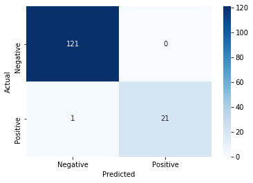

```python
sns.heatmap(
    mod_cm(braca_gene_df,mychoice_df, ld_df),
    annot=True,
    cmap='Blues',
    fmt='g'
)
plt.show()
```

```python
print('Sensitivity (True Positive Rate): ', model_metrics[0])
print('Specificity (True Negative Rate): ', model_metrics[3])
print('Fallout (False Positive Rate): ', model_metrics[1])
print('Precision: ', model_metrics[2])
print('F1 Score: ', model_metrics[4])
```

```
Sensitivity (True Positive Rate):  0.9545454545454546
Specificity (True Negative Rate):  1.0
Fallout (False Positive Rate):  0.0
Precision:  1.0
F1 Score:  0.9767441860465117
```

```python
genes_act = pd.read_excel('validation_data.xlsx', converters={'MRN': str}, sheet_name='genes')
genes_act = genes_act[pd.isna(genes_act['Genes actual']) == False]
genes_act['Gene'] = genes_act['Genes actual']
genes_act['gid'] = genes_act.apply(lambda x: str(x.MRN) + x['Genes actual'], axis=1)
genes_act = genes_act[['gid', 'Genes actual']]

g_df = genes_df[['MRN','Gene']].copy()
g_df = g_df[pd.isna(g_df.Gene) == False]
g_df['Gene Pred'] = g_df['Gene']
g_df['gid'] = g_df.apply(lambda x: str(x.MRN) + x['Gene Pred'], axis=1)
g_df = g_df[['gid', 'Gene Pred']]

g_eval = pd.merge(genes_act, g_df, on='gid', how='left')
g_eval['concordance'] = g_eval.apply(lambda x: 1 if x['Genes actual'] == x['Gene Pred'] else 0, axis=1)
```

```python
g_eval.concordance.sum() / len(g_eval) # accuracy for gene id
```

```
0.9310344827586207
```

### Model run for increment of 5 from 0 to 100 levenschtein similarity ratio

!! takes approximately a full day to run below code

```python
tpr = []
fpr = []
dfs = {}
threshold = [i * 5 for i in range(21)]

for i in threshold:
    braca_gene_df, mychoice_df, genes_df, ld_df = run_model(i)
    pos_neg_df = mod_eval(braca_gene_df,mychoice_df, ld_df)
    dfs.update({i: pos_neg_df})

    pos_neg_cf = mod_cm(braca_gene_df,mychoice_df, ld_df)
    mets = mod_metrics(pos_neg_cf)
    tpr.append(mets[0])
    fpr.append(mets[1])

print('Sensitivity (True Positive Rate): ', mets[0])
print('Specificity (True Negative Rate): ', mets[3])
print('Fallout (False Positive Rate): ', mets[1])
print('Precision: ', mets[2])
print('F1 Score: ', mets[4])
```

```python
pd.DataFrame({
    'Threshold': [i * 5 for i in range(21)],
    'results': [dfs[i].result_pred.unique() for i in [i * 5 for i in range(21)] ],
    'tpr': tpr,
    'fpr': fpr
}).to_excel('threshold_tpr_fpr.xlsx', index=False)
```